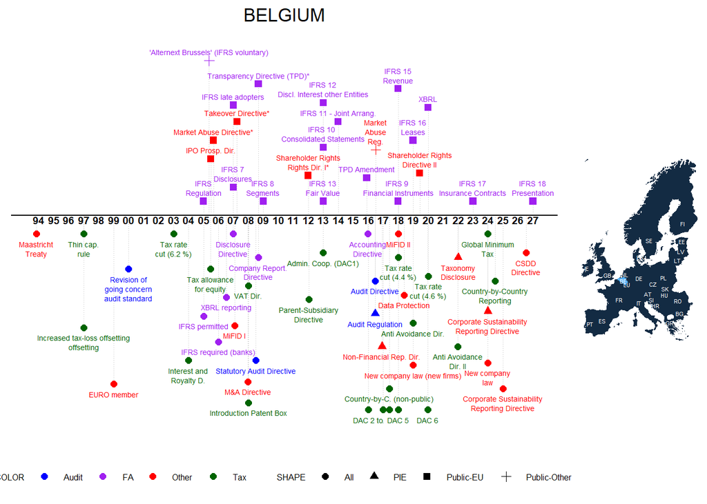

Notes: The graph depicts major regulatory changes that we identified via an extensive literature search, an online survey of mentioned authors, and other sources. Please note that the graph does not include all possible regulatory changes, e.g. minor revisions to local GAAP or tax rate changes below 3% are not included. The dates of EU Directives are based on the official transposition deadlines unless denoted with a *, in which case we included the entry-to-force date as identified in the literature. For more information, please go to [Labro and Pierk (2023)](http://www.eu-regulations.com/Labro_Pierk_2023.pdf). We kindly ask that you cite the paper if you use the information on this website in your research project. Do you have comments or see anything missing? Please email us!

## Regulations, Publications, Further Graphs

The tab ‘Regulations’ includes links to the regulations, gives short descriptions, and provides selective papers for further reading. If the regulation is a national transposition of an EU Directive, the link to the Directive is given. The tab ‘Number of Regulations’ shows graphically the number of regulations 8 years around the respective year (-4,-3,-2,-1,0,+1,+2,+3). The tab ‘Number of Categories” shows graphically the number of different categories 8 years around the respective year (-4,-3,-2,-1,0,+1,+2,+3). The tab ’Publications’ shows all publications that include the countries’ names and variations thereof in the title, abstract, or keywords. Similarly, the tab ‘SSRN’ shows papers of the SSRN Accouning Research Network that include the countries’ names and variations.

### Regulations

[output not shown]

[output cut: 57 more lines]

### Number of Regulations

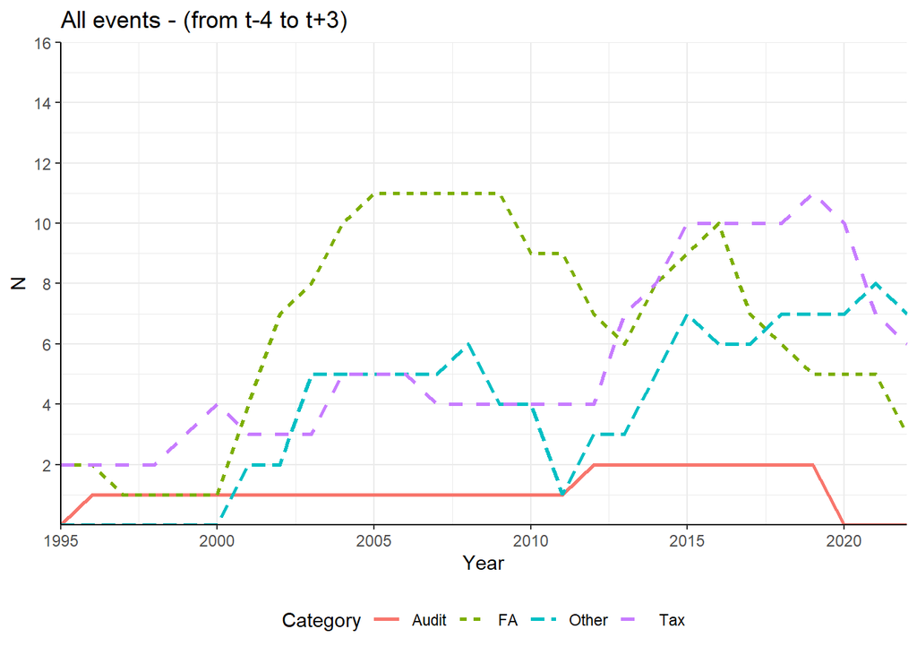

### Number of Categories

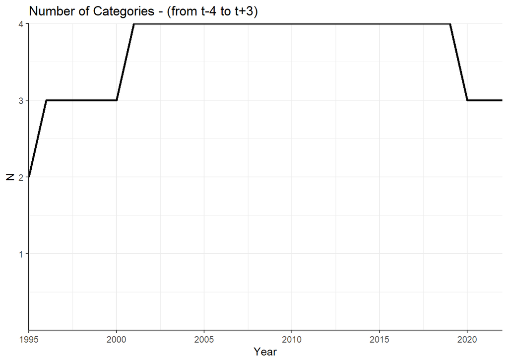

### Publications

|  | authors | title | year | journal |
| --- | --- | --- | --- | --- |
| 1 | Hardies K., Lennox C., Li B. | gender discrimination? evidence from the belgian public accounting profession* | 2021 | Contemporary Accounting Research |
| 2 | Na K., Yan W. | languages and corporate tax avoidance | 2021 | Review of Accounting Studies |
| 3 | Vandenhaute M.-L., Hardies K., Breesch D. | professional and commercial incentives in audit firms: evidence on partner compensation | 2020 | European Accounting Review |
| 4 | van Raak J., Peek E., Meuwissen R., Schelleman C. | the effect of audit market structure on audit quality and audit pricing in the private-client market | 2020 | Journal of Business Finance and Accounting |
| 5 | Dekeyser S., Gaeremynck A., Willekens M. | evidence of industry scale effects on audit hours, billing rates, and pricing | 2019 | Contemporary Accounting Research |
| 6 | Everaert P., Bouten L., Baele A. | csr website disclosure: the influence of the upper echelons | 2019 | Accounting, Auditing and Accountability Journal |
| 7 | De Meyere M., Vander Bauwhede H., Van Cauwenberge P. | the impact of financial reporting quality on debt maturity: the case of private firms | 2018 | Accounting and Business Research |
| 8 | Deloof M., Vanacker T. | the recent financial crisis, start-up financing and survival | 2018 | Journal of Business Finance and Accounting |
| 9 | Hardies K., Vandenhaute M.-L., Breesch D. | an analysis of auditors’ going-concern reporting accuracy in private firms | 2018 | Accounting Horizons |
| 10 | Hoozée S., Ngo Q.-H. | the impact of managers’ participation in costing system design on their perceived contributions to process improvement | 2018 | European Accounting Review |

[output cut: 46 more lines]

### SSRN

|  | authors | title | Posted | Revised |
| --- | --- | --- | --- | --- |
| 1 | Evelyn Van der Hauwaert, Sophie Hoozée, Sophie Maussen and Werner Bruggeman | the impact of enabling performance measurement on managers’ autonomous work motivation and performance | 2021-12-22 |  |
| 2 | Ke Na and Wenjia Yan | languages and corporate tax avoidance | 2021-04-03 |  |
| 3 | Christophe Van Linden, Marie-Laure Vandenhaute and Ally Zimmerman | audit firm employee turnover and audit quality | 2021-03-22 |  |
| 4 | Sophie Hoozée, Sophie Maussen, Werner Bruggeman and Geert Scheipers | fitting responsibility center structures to strategy: bakery products international | 2020-11-04 | 2021-02-02 |
| 5 | Leentje Moortgat, Jan Annaert and Marc Deloof | the long-run persistence of dividend policy | 2020-07-07 |  |